# Year TOTAL Dissimilarity NULL Models (reshuffle and cyclic shift)

This code is Script 4a for Kitchel et al. Biotic homogenization, the exception and not the rule for marine fish communities manuscript.

- This project is a collaborative effort to describe changes in taxonomic composition of fish communities around the world–as sampled by bottom trawl surveys.

“A null model is a pattern-generating model based on randomization of ecological data and is designed to produce a pattern that would be expected in the absence of a particular ecological mechanism (Gotelli and Graves 1996; Gotelli and McGill 2006).” Ryosuke Nakadai et al 2021

- Code by Zoë J. Kitchel

```r
library(data.table)
library(vegan)
library(sf)
library(concaveman) #polygon around points
library(betapart) #allows us to partition beta diversity
library(geosphere)
library(ggpubr) #stat_regline_equation
library(nlme)
library(mgcv) #to make gam
library(cowplot)
library(lme4)

#Pull Dissimilarity Means
distances_dissimilarities_allyears.r <- readRDS(here::here("output", "dissimilarities", "distances_dissimilarities_allyears.r.rds"))

#make survey and survey unit factors
distances_dissimilarities_allyears.r[,survey:=factor(survey)][,survey_unit:=factor(survey_unit)]

#adjust years
distances_dissimilarities_allyears.r[,year_adj := year-min(year)+1]

#add new variable for year in sequence per region
distances_dissimilarities_allyears.r[,first_year := min(year),.(survey_unit)]
distances_dissimilarities_allyears.r[,last_year := max(year),.(survey_unit)]

#distances_dissimilarities_allyears.r[,year_in_seq := year-first_year+1]

distances_dissimilarities_allyears.r[,years_sampled := last_year-first_year+1]
```

###Palette for Plotting Palette for plotting all 42 survey units

```r
survey_unit.list <- levels(factor(distances_dissimilarities_allyears.r[,survey_unit]))

palette_42 <- c(
  "#5A5156", #AI
  "#DF00DB", #BITS-1
  "#DB8EDA", #BITS-4
  "#F6222E", #CHL
  "#F8A19F", #DFO-NF
  "#16FF32", #DFO-QCS
  "#325A9B", #EBS
  "#3283FE", #EVHOE
  "#FEAF16", #FR-CGFS
  "#fccb6d", #GMEX-Fall
  "#1C8356", #GMEX-Summer
  "#C4451C", #GOA
  "#85660D", #GRL-DE
  "#B0009F", #GSL-N
  "#BF79B8", #GSL-S
  "#1CBE4F", #ICE-GFS
  "#782AB6", #IE-IGFS
  "#90AD1C", #MEDITS
  "#6B003A", #NAM
  "#A75B00", #NEUS-Fall
  "#E3B072", #NEUS-Spring
  "#02E8B6", #NIGFS-1
  "#97E7D5", #NIGFS-4
  "#B00068", #Nor-BTS-3
  "#00B9E3", #NS-IBTS-1
  "#95E2F4", #NS-IBTS-3
  "#B3CE73", #NZ-CHAT
  "#689500", #NZ-ECSI
  "#364d02",#NZ-SUBA
  "#AAF400", #NZ-WCSI
  "#AA0DFE", #PT-IBTS
  "#7f9eb8", #ROCKALL
  "#FA0087", #S-GEORG
  "#DEA0FD", #SCS-Summer
  "#FCEF88", #SEUS-fall
  "#A59405", #SEUS-spring
  "#FCE100", #SEUS-summer
  "#544563", #SWC-IBTS-1
  "#a37fc7", #SWC-IBTS-4
  "#C075A6", #WCANN
  "#BDCDFF", #ZAF-ATL
  "#003EFF"  #ZAF-IND
)

color_link <- data.table(survey_unit = survey_unit.list,hex = palette_42)
```

Add names for plotting

```r
name_helper <- data.table(Survey_Name_Season = c("Aleutian Islands",
                                    "Baltic Sea Q1",
                                    "Baltic Sea Q4",
                                    "Chile",
                                    "Newfoundland",
                                    "Queen Charlotte Sound",
                                    "Eastern Bering Sea",
                                    "Bay of Biscay",
                                    "English Channel",
                                    "Gulf of Mexico Summer",
                                    "Gulf of Alaska",
                                    "Greenland",
                                    "N Gulf of St. Lawrence",
                                    "S Gulf of St. Lawrence",
                                    "Iceland",
                                    "Irish Sea",
                                    "Mediterranean",
                                    "Namibia",
                                    "NE US Fall",
                                    "NE US Spring",
                                    "N Ireland Q1",
                                    "N Ireland Q4",
                                    "Barents Sea Norway Q3",
                                    "N Sea Q1",
                                    "N Sea Q3",
                                    "Chatham Rise NZ",
                                    "E Coast S Island NZ",
                                    "W Coast S Island NZ",
                                    "Portugal",
                                    "S Georgia",
                                  "Scotian Shelf Summer",
                                  "SE US Fall",
                                  "SE US Spring",
                                  "SE US Summer",
                                  "W Coast US",
                                  "Atlantic Ocean ZA",
                                  "Indian Ocean ZA",
                                   "Rockall Plateau",
                                  "Scotland Shelf Sea Q1",
                                  "Scotland Shelf Sea Q4",
                                  "Falkland Islands",
                                  "Gulf of Mexico Fall",
                                  "Barents Sea Norway Q1",
                                  "Sub-Antarctic NZ",
                                  "Scotian Shelf Spring"),
                          survey_unit = c(
                                  "AI",
                                  "BITS-1",
                                  "BITS-4",
                                  "CHL",
                                  "DFO-NF",
                                  "DFO-QCS",
                                  "EBS",
                                  "EVHOE",
                                  "FR-CGFS",
                                  "GMEX-Summer",
                                  "GOA",
                                  "GRL-DE",
                                  "GSL-N",
                                  "GSL-S",
                                  "ICE-GFS",
                                  "IE-IGFS",
                                  "MEDITS",
                                  "NAM",
                                  "NEUS-Fall",
                                  "NEUS-Spring",
                                  "NIGFS-1",
                                  "NIGFS-4",
                                  "Nor-BTS-3",
                                  "NS-IBTS-1",
                                  "NS-IBTS-3",
                                  "NZ-CHAT",
                                  "NZ-ECSI",
                                  "NZ-WCSI",
                                  "PT-IBTS",
                                  "S-GEORG",
                                  "SCS-SUMMER",
                                  "SEUS-fall",
                                  "SEUS-spring",
                                  "SEUS-summer",
                                  "WCANN",
                                  "ZAF-ATL",
                                  "ZAF-IND",
                                  "ROCKALL",
                                  "SWC-IBTS-1",
                                  "SWC-IBTS-4",
                                  "FALK",
                                  "GMEX-Fall",
                                  "Nor-BTS-1",
                                  "NZ-SUBA",
                                  "SCS-SPRING"
                          ))


color_link <- name_helper[color_link, on = "survey_unit"]
```

Load up ‘true slopes’ and CIs for comparison

```r
BC_total_model_coefs_reduced_length.unique <- readRDS(here::here("output","region_stats","BC_total_model_coefs_reduced_length.unique.Rds"))
```

#NULL MODEL CONSTUCTION ##1) Reshuffle years (maintain correlation among species, removes autocorrelation within a species)

I need to: - reshuffle years - reassign years - run lmer - pull mean and CI for each region

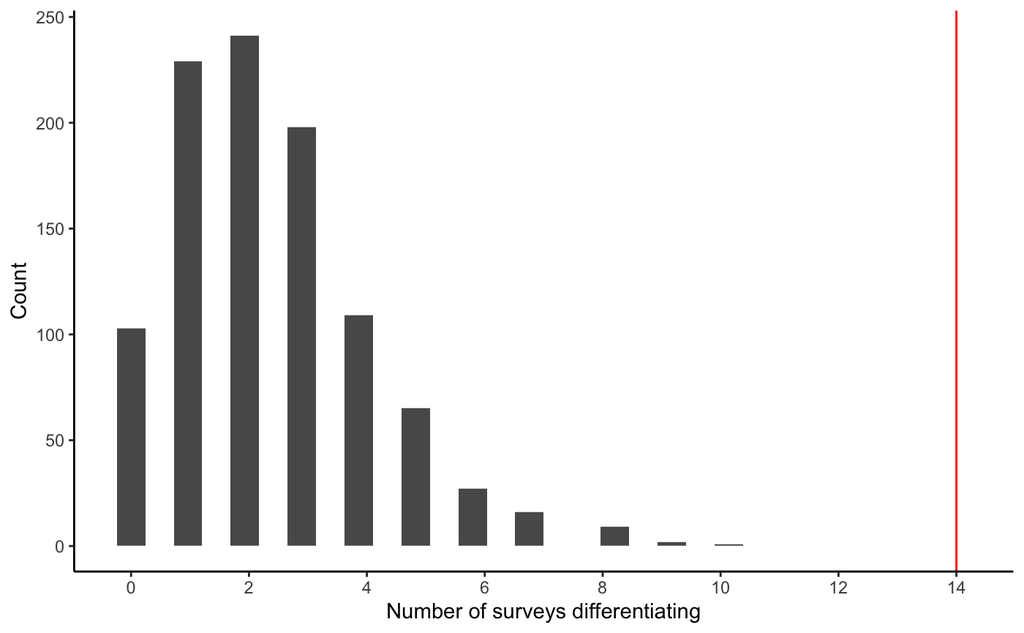

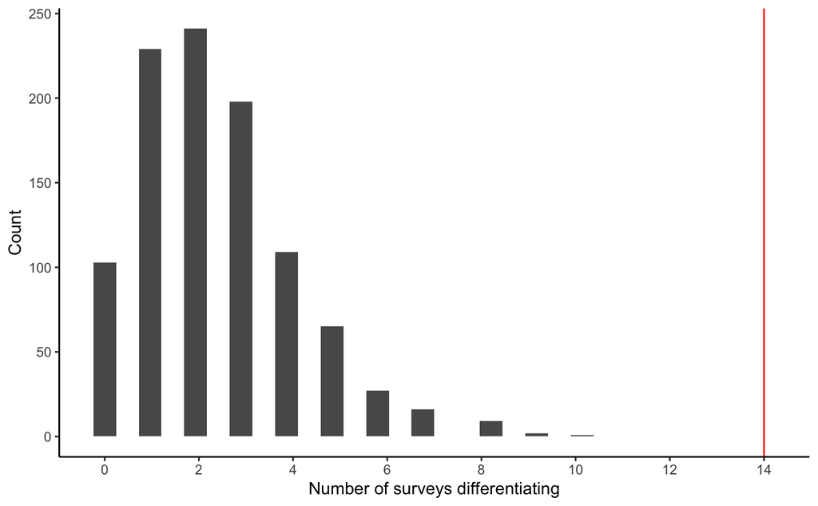

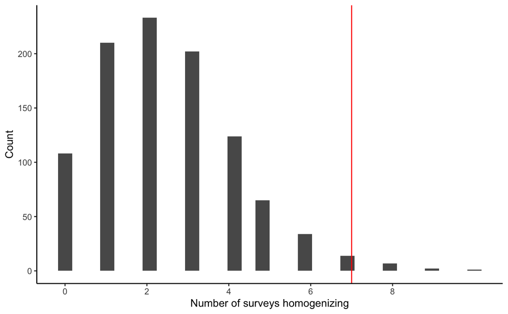

```r
(reshuffle_differentiation_plot <- ggplot() +
  geom_histogram(data = all_null_runs_reshuffle_year[run != "observed",], aes(differentiating)) +
#  geom_vline(xintercept = all_null_runs_reshuffle_year[run == "observed",]$differentiating, color = "red") +
      geom_vline(xintercept = 14, color = "red") +
    scale_x_continuous(breaks = seq(0,15,by = 2)) +
  labs(x = "Number of surveys differentiating", y = "Count") +
  theme_classic())
(reshuffle_differentiation_plot <- ggplot() +
  geom_histogram(data = all_null_runs_reshuffle_year[run != "observed",], aes(differentiating)) +
#  geom_vline(xintercept = all_null_runs_reshuffle_year[run == "observed",]$differentiating, color = "red") +
      geom_vline(xintercept = 14, color = "red") +
    scale_x_continuous(breaks = seq(0,15,by = 2)) +
  labs(x = "Number of surveys differentiating", y = "Count") +
  theme_classic())

(reshuffle_homogenizing_plot <- ggplot() +
  geom_histogram(data = all_null_runs_reshuffle_year[run != "observed",], aes(homogenizing)) +
#  geom_vline(xintercept = all_null_runs_reshuffle_year[run == "observed",]$homogenizing, color = "red") +
      geom_vline(xintercept = 7, color = "red") +
    scale_x_continuous(breaks = seq(0,8,by = 2)) +
  labs(x = "Number of surveys homogenizing", y = "Count") +
  theme_classic())
```

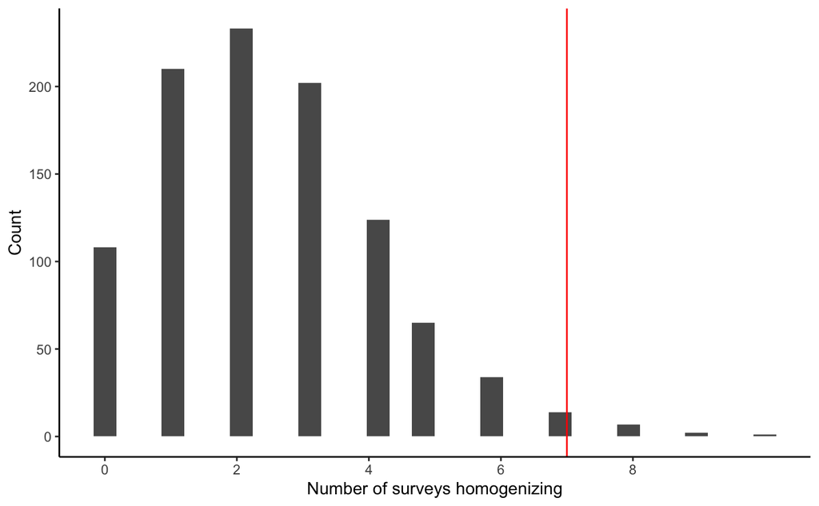

```r
(reshuffle_homogenizing_plot <- ggplot() +
  geom_histogram(data = all_null_runs_reshuffle_year[run != "observed",], aes(homogenizing)) +
#  geom_vline(xintercept = all_null_runs_reshuffle_year[run == "observed",]$homogenizing, color = "red") +
      geom_vline(xintercept = 7, color = "red") +
    scale_x_continuous(breaks = seq(0,8,by = 2)) +
  labs(x = "Number of surveys homogenizing", y = "Count") +
  theme_classic())
reshuffle_null_plot <- cowplot::plot_grid(reshuffle_differentiation_plot, reshuffle_homogenizing_plot,
                                     ncol = 2)
ggsave(reshuffle_null_plot, path = here::here("figures"), filename = "reshuffle_null_plot.jpg", width = 6.5, height = 3)
```

##2) Vary start year (maintain correlation among species and autocorrelation within a species, but introduces weird breakpoints)

I need to: - pick random starting years - reassign years - run lmer - pull mean and CI for each region

```r
for (i in 1:length(years_adj)){

  BC_dissimilarity_time <- distances_dissimilarities_allyears.r[,.(survey_unit, year, year_adj, bray_curtis_dissimilarity_total_mean)]

 # start_year <- sample(1:length(years_adj), 1)
  start_year <- years_adj[i]

  random_sequence <- c(years_adj[start_year:length(years_adj)],years_adj[1:start_year-1])

  year_run_key <- data.table(year_adj = years_adj, years_adj_null = random_sequence)

  BC_dissimilarity_time  <- BC_dissimilarity_time[year_run_key, on = "year_adj"]

  #run overall model
  bray_curtis_total_lmer <- lmer(bray_curtis_dissimilarity_total_mean ~ years_adj_null + (1 + years_adj_null|survey_unit),data = BC_dissimilarity_time)


  bray_curtis_total_coefs <- data.table(coef(bray_curtis_total_lmer)[[1]])
  bray_curtis_total_coefs[,survey_unit := rownames(coef(bray_curtis_total_lmer)[[1]])][,Year_slope := signif(years_adj_null,3)][,Intercept := signif(`(Intercept)`,3)]
  bray_curtis_total_coefs <- bray_curtis_total_coefs[color_link, on = "survey_unit"]

  bray_curtis_total_coefs[,run := i]

  bray_curtis_total_coefs.exp <- bray_curtis_total_coefs[,.(run, Survey_Name_Season, survey_unit, Intercept, Year_slope)]

  if(i == 1){
     all_null_runs_cyclic_shift <- bray_curtis_total_coefs.exp }else{
    all_null_runs_cyclic_shift <- rbind(all_null_runs_cyclic_shift, bray_curtis_total_coefs.exp)
   }
  print(i)
}
```

```
[1] 1
```

```
[1] 2
```

```
[1] 3
[1] 4
```

```
[1] 5
```

```
[1] 6
```

```
[1] 7
```

```
[1] 8
```

```
[1] 9
```

```
[1] 10
[1] 11
```

```
[1] 12
```

```
[1] 13
```

```
[1] 14
```

```
[1] 15
```

```
[1] 16
```

```
[1] 17
```

```
[1] 18
```

```
[1] 19
```

```
[1] 20
```

```
[1] 21
[1] 22
[1] 23
```

```
[1] 24
```

```
[1] 25
[1] 26
[1] 27
[1] 28
[1] 29
```

```
[1] 30
```

```
[1] 31
[1] 32
```

```
[1] 33
[1] 34
```

```
[1] 35
```

```
[1] 36
```

```
[1] 37
```

```
[1] 38
```

```
[1] 39
```

```
[1] 40
```

```
[1] 41
```

```
[1] 42
```

```r
errorbar_null_models_merge <- plot_grid(errorbar_slope_year_reshuffle + theme(axis.title.x = element_blank(), axis.text.x =element_blank()), errorbar_slope_year_cyclic_shift, ncol = 1, labels = c("a.","b."), vjust = 1, hjust = -0.2)

ggsave(errorbar_null_models_merge, filename = "errorbar_null_models_merge.jpg", path = here::here("figures"), height = 9, width = 10)
```